# CS 422 Section 01 hw1

Rui Zou A20351034

## 2.1 Problem 1

#### (a)(b)

```r
setwd("/Users/rzou/Academics/Courses/CS422 - Data Mining/hw1")
college = read.csv("College.csv", header=T, sep=",")
rownames(college) <- college[ , 1]
college <- college[ , -1]
college
```

|  | Private | Apps | Accept | Enroll | Top10perc | Top25perc | F.Undergrad | P.Undergrad | Outstate | Room.Board | Books | Personal | PhD | Terminal | S.F.Ratio | perc.alumni | Expend | Grad.Rate |
| --- | --- | --- | --- | --- | --- | --- | --- | --- | --- | --- | --- | --- | --- | --- | --- | --- | --- | --- |
| Abilene Christian University | Yes | 1660 | 1232 | 721 | 23 | 52 | 2885 | 537 | 7440 | 3300 | 450 | 2200 | 70 | 78 | 18.1 | 12 | 7041 | 60 |
| Adelphi University | Yes | 2186 | 1924 | 512 | 16 | 29 | 2683 | 1227 | 12280 | 6450 | 750 | 1500 | 29 | 30 | 12.2 | 16 | 10527 | 56 |
| Adrian College | Yes | 1428 | 1097 | 336 | 22 | 50 | 1036 | 99 | 11250 | 3750 | 400 | 1165 | 53 | 66 | 12.9 | 30 | 8735 | 54 |
| Agnes Scott College | Yes | 417 | 349 | 137 | 60 | 89 | 510 | 63 | 12960 | 5450 | 450 | 875 | 92 | 97 | 7.7 | 37 | 19016 | 59 |
| Alaska Pacific University | Yes | 193 | 146 | 55 | 16 | 44 | 249 | 869 | 7560 | 4120 | 800 | 1500 | 76 | 72 | 11.9 | 2 | 10922 | 15 |
| Albertson College | Yes | 587 | 479 | 158 | 38 | 62 | 678 | 41 | 13500 | 3335 | 500 | 675 | 67 | 73 | 9.4 | 11 | 9727 | 55 |
| Albertus Magnus College | Yes | 353 | 340 | 103 | 17 | 45 | 416 | 230 | 13290 | 5720 | 500 | 1500 | 90 | 93 | 11.5 | 26 | 8861 | 63 |
| Albion College | Yes | 1899 | 1720 | 489 | 37 | 68 | 1594 | 32 | 13868 | 4826 | 450 | 850 | 89 | 100 | 13.7 | 37 | 11487 | 73 |
| Albright College | Yes | 1038 | 839 | 227 | 30 | 63 | 973 | 306 | 15595 | 4400 | 300 | 500 | 79 | 84 | 11.3 | 23 | 11644 | 80 |
| Alderson-Broaddus College | Yes | 582 | 498 | 172 | 21 | 44 | 799 | 78 | 10468 | 3380 | 660 | 1800 | 40 | 41 | 11.5 | 15 | 8991 | 52 |

[output cut: 767 more lines]

#### (c)

```r
summary(college)
```

```
 Private        Apps           Accept          Enroll       Top10perc
 No :212   Min.   :   81   Min.   :   72   Min.   :  35   Min.   : 1.00
 Yes:565   1st Qu.:  776   1st Qu.:  604   1st Qu.: 242   1st Qu.:15.00
           Median : 1558   Median : 1110   Median : 434   Median :23.00
           Mean   : 3002   Mean   : 2019   Mean   : 780   Mean   :27.56
           3rd Qu.: 3624   3rd Qu.: 2424   3rd Qu.: 902   3rd Qu.:35.00
           Max.   :48094   Max.   :26330   Max.   :6392   Max.   :96.00
   Top25perc      F.Undergrad     P.Undergrad         Outstate       Room.Board
 Min.   :  9.0   Min.   :  139   Min.   :    1.0   Min.   : 2340   Min.   :1780
 1st Qu.: 41.0   1st Qu.:  992   1st Qu.:   95.0   1st Qu.: 7320   1st Qu.:3597
 Median : 54.0   Median : 1707   Median :  353.0   Median : 9990   Median :4200
 Mean   : 55.8   Mean   : 3700   Mean   :  855.3   Mean   :10441   Mean   :4358
 3rd Qu.: 69.0   3rd Qu.: 4005   3rd Qu.:  967.0   3rd Qu.:12925   3rd Qu.:5050
 Max.   :100.0   Max.   :31643   Max.   :21836.0   Max.   :21700   Max.   :8124
     Books           Personal         PhD            Terminal       S.F.Ratio
 Min.   :  96.0   Min.   : 250   Min.   :  8.00   Min.   : 24.0   Min.   : 2.50
 1st Qu.: 470.0   1st Qu.: 850   1st Qu.: 62.00   1st Qu.: 71.0   1st Qu.:11.50
 Median : 500.0   Median :1200   Median : 75.00   Median : 82.0   Median :13.60
 Mean   : 549.4   Mean   :1341   Mean   : 72.66   Mean   : 79.7   Mean   :14.09
 3rd Qu.: 600.0   3rd Qu.:1700   3rd Qu.: 85.00   3rd Qu.: 92.0   3rd Qu.:16.50
 Max.   :2340.0   Max.   :6800   Max.   :103.00   Max.   :100.0   Max.   :39.80
  perc.alumni        Expend        Grad.Rate
 Min.   : 0.00   Min.   : 3186   Min.   : 10.00
 1st Qu.:13.00   1st Qu.: 6751   1st Qu.: 53.00
 Median :21.00   Median : 8377   Median : 65.00
 Mean   :22.74   Mean   : 9660   Mean   : 65.46
 3rd Qu.:31.00   3rd Qu.:10830   3rd Qu.: 78.00
 Max.   :64.00   Max.   :56233   Max.   :118.00
```

#### (c)

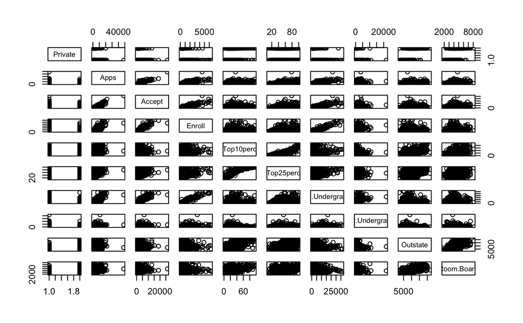

```r
par(family='Arial Unicode MS')
pairs(college[ , 1:10])
```

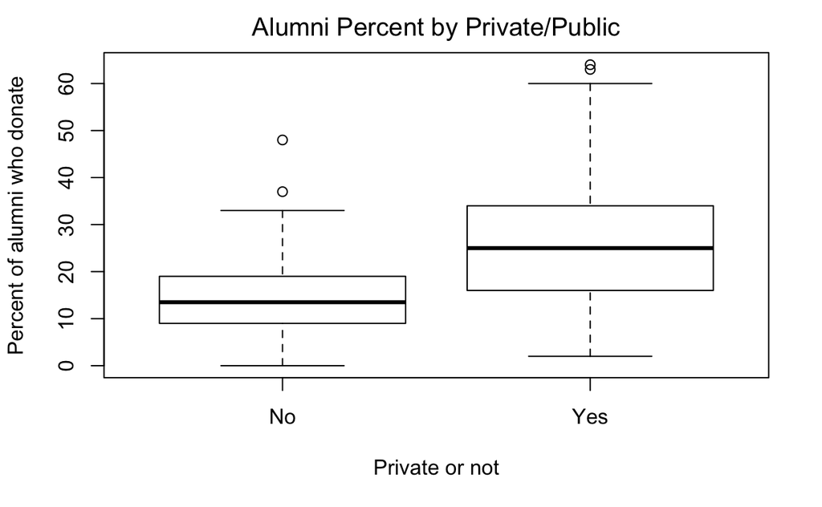

```r
# boxplot of perc.alumni by public/private
par(family='Arial Unicode MS')
boxplot(perc.alumni~Private, data=college, main="Alumni Percent by Private/Public",
        xlab="Private or not", ylab="Percent of alumni who donate")
```

We can see that alumni who go to private schools donate more to their colleges.

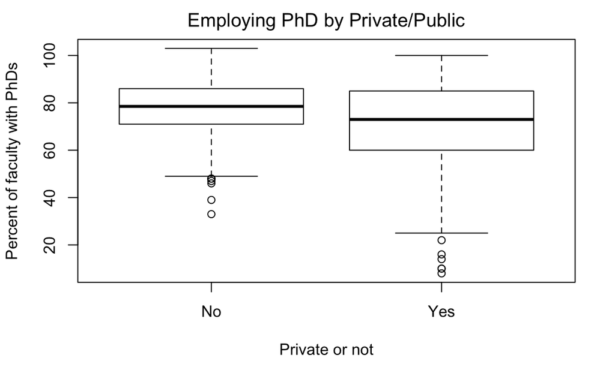

```r
# boxplot of PhD by public/private
par(family='Arial Unicode MS')
boxplot(PhD~Private, data=college, main="Employing PhD by Private/Public",
        xlab="Private or not", ylab="Percent of faculty with PhDs")
```

We can see that public colleges employ more PhDs.

```r
Elite <- rep("No", nrow(college))
Elite[college$Top10perc > 50] <- "Yes"
Elite <- as.factor(Elite)
college <- data.frame(college, Elite)
summary(college)
```

```
 Private        Apps           Accept          Enroll       Top10perc
 No :212   Min.   :   81   Min.   :   72   Min.   :  35   Min.   : 1.00
 Yes:565   1st Qu.:  776   1st Qu.:  604   1st Qu.: 242   1st Qu.:15.00
           Median : 1558   Median : 1110   Median : 434   Median :23.00
           Mean   : 3002   Mean   : 2019   Mean   : 780   Mean   :27.56
           3rd Qu.: 3624   3rd Qu.: 2424   3rd Qu.: 902   3rd Qu.:35.00
           Max.   :48094   Max.   :26330   Max.   :6392   Max.   :96.00
   Top25perc      F.Undergrad     P.Undergrad         Outstate       Room.Board
 Min.   :  9.0   Min.   :  139   Min.   :    1.0   Min.   : 2340   Min.   :1780
 1st Qu.: 41.0   1st Qu.:  992   1st Qu.:   95.0   1st Qu.: 7320   1st Qu.:3597
 Median : 54.0   Median : 1707   Median :  353.0   Median : 9990   Median :4200
 Mean   : 55.8   Mean   : 3700   Mean   :  855.3   Mean   :10441   Mean   :4358
 3rd Qu.: 69.0   3rd Qu.: 4005   3rd Qu.:  967.0   3rd Qu.:12925   3rd Qu.:5050
 Max.   :100.0   Max.   :31643   Max.   :21836.0   Max.   :21700   Max.   :8124
     Books           Personal         PhD            Terminal       S.F.Ratio
 Min.   :  96.0   Min.   : 250   Min.   :  8.00   Min.   : 24.0   Min.   : 2.50
 1st Qu.: 470.0   1st Qu.: 850   1st Qu.: 62.00   1st Qu.: 71.0   1st Qu.:11.50
 Median : 500.0   Median :1200   Median : 75.00   Median : 82.0   Median :13.60
 Mean   : 549.4   Mean   :1341   Mean   : 72.66   Mean   : 79.7   Mean   :14.09
 3rd Qu.: 600.0   3rd Qu.:1700   3rd Qu.: 85.00   3rd Qu.: 92.0   3rd Qu.:16.50
 Max.   :2340.0   Max.   :6800   Max.   :103.00   Max.   :100.0   Max.   :39.80
  perc.alumni        Expend        Grad.Rate      Elite
 Min.   : 0.00   Min.   : 3186   Min.   : 10.00   No :699
 1st Qu.:13.00   1st Qu.: 6751   1st Qu.: 53.00   Yes: 78
 Median :21.00   Median : 8377   Median : 65.00
 Mean   :22.74   Mean   : 9660   Mean   : 65.46
 3rd Qu.:31.00   3rd Qu.:10830   3rd Qu.: 78.00
 Max.   :64.00   Max.   :56233   Max.   :118.00
```

There are 78 elite universities.

```r
par(family='Arial Unicode MS')
par(mfrow=c(2,2))
hist(college$Enroll, xlab="Number of new students enrolled", main="Histogram of Enroll")
hist(college$F.Undergrad, xlab="Number of full-time undergraduates", main="Histogram of Full-time Undergraduates")
```

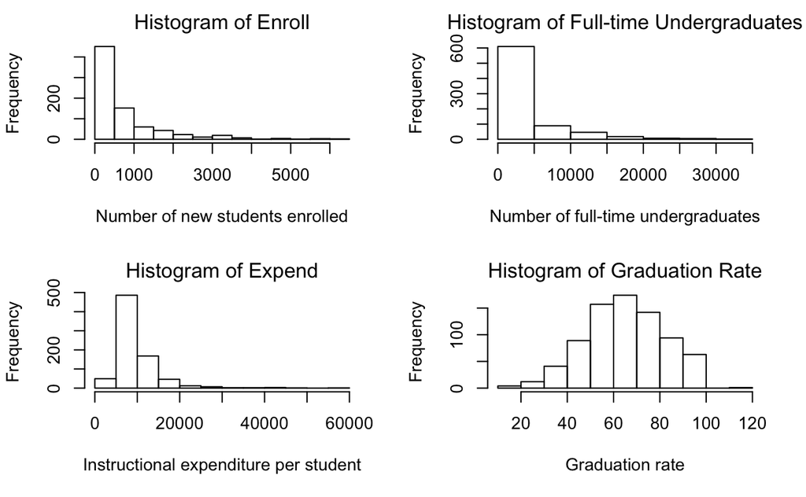

```r
hist(college$Expend, xlab="Instructional expenditure per student", main="Histogram of Expend")
hist(college$Grad.Rate, xlab="Graduation rate", main="Histogram of Graduation Rate")
```

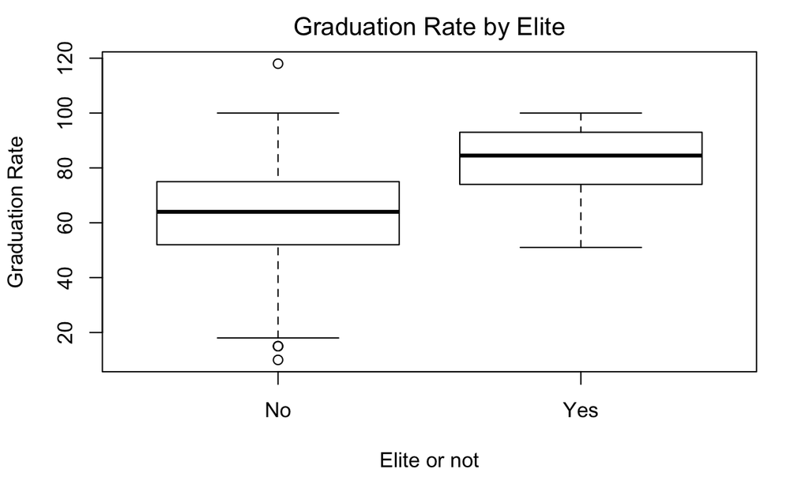

```r
par(family='Arial Unicode MS')
boxplot(Grad.Rate~Elite, data=college, main="Graduation Rate by Elite",
        xlab="Elite or not", ylab="Graduation Rate")
```

We can see that Elite colleges have remarkably better graduation rates than non-elite colleges.

## 2.2 Problem 2

#### (a)

```r
df = read.csv("nba.csv", header=T, sep=",")
head(df)
```

|  | SEASON | DATE | PLAYER.FULLNAME | POSITION | OWNTEAM | OPPTEAM | VENUE | MIN | FG | FGA | X3P | X3PA | FT | FTA | OR | DR | TOT | A | PF | ST | TO | BL | PTS |
| --- | --- | --- | --- | --- | --- | --- | --- | --- | --- | --- | --- | --- | --- | --- | --- | --- | --- | --- | --- | --- | --- | --- | --- |
| 1 | 2017-2018 Regular Season | 10/17/2017 | Gordon Hayward | SF | Boston | Cleveland | R | 5.3 | 1 | 2 | 0 | 1 | 0 | 0 | 0 | 1 | 1 | 0 | 1 | 0 | 0 | 0 | 2 |
| 2 | 2017-2018 Regular Season | 10/17/2017 | Jayson Tatum | SF | Boston | Cleveland | R | 36.5 | 5 | 12 | 1 | 2 | 3 | 3 | 4 | 6 | 10 | 3 | 4 | 0 | 1 | 0 | 14 |
| 3 | 2017-2018 Regular Season | 10/17/2017 | Al Horford | C | Boston | Cleveland | R | 32.1 | 2 | 7 | 0 | 2 | 5 | 7 | 0 | 7 | 7 | 5 | 2 | 0 | 0 | 1 | 9 |
| 4 | 2017-2018 Regular Season | 10/17/2017 | Jaylen Brown | SF | Boston | Cleveland | R | 39.6 | 11 | 23 | 2 | 9 | 1 | 2 | 1 | 5 | 6 | 0 | 5 | 2 | 3 | 0 | 25 |
| 5 | 2017-2018 Regular Season | 10/17/2017 | Kyrie Irving | PG | Boston | Cleveland | R | 39.4 | 8 | 17 | 4 | 9 | 2 | 2 | 2 | 2 | 4 | 10 | 4 | 3 | 2 | 0 | 22 |
| 6 | 2017-2018 Regular Season | 10/17/2017 | Marcus Smart | PG | Boston | Cleveland | R | 35.1 | 5 | 16 | 0 | 4 | 2 | 3 | 0 | 9 | 9 | 3 | 2 | 2 | 2 | 2 | 12 |

```r
# test correlation between all the numeric predictors and the response.
for (i in 1:ncol(df)){
  if (is.numeric(df[[i]]))
    cat(colnames(df)[i],"\t", cor(x=df[[i]], y=df$PTS, method='pearson'), "\n")
}
```

```
MIN      0.7197779
FG   0.9574147
FGA      0.86671
X3P      0.5405349
X3PA     0.5385442
FT   0.6393178
FTA      0.6275821
OR   0.3545015
DR   0.4567507
TOT      0.4916305
A    0.3800708
PF   0.257021
ST   0.2716636
TO   0.4368736
BL   0.2173254
PTS      1
```

We choose the predictor “FG” because it has the largest positive correlation coefficient.

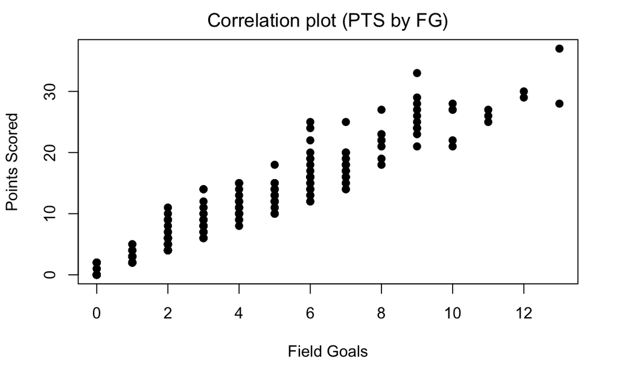

```r
par(family='Arial Unicode MS')
attach(df)
plot(FG, PTS, main="Correlation plot (PTS by FG)", xlab="Field Goals", ylab="Points Scored", pch=19)
```

```r
# simple linear regression
slr <- lm(PTS~FG, data=df)
summary(slr)
```

```
Call:
lm(formula = PTS ~ FG, data = df)

Residuals:
    Min      1Q  Median      3Q     Max
-5.7986 -1.2524 -0.3616  0.8569  9.4199

Coefficients:
            Estimate Std. Error t value Pr(>|t|)
(Intercept)  0.58848    0.22751   2.587   0.0102 *
FG           2.55462    0.04715  54.186   <2e-16 ***
---
Signif. codes:  0 ‘***’ 0.001 ‘**’ 0.01 ‘*’ 0.05 ‘.’ 0.1 ‘ ’ 1

Residual standard error: 2.241 on 267 degrees of freedom
Multiple R-squared:  0.9166,    Adjusted R-squared:  0.9163
F-statistic:  2936 on 1 and 267 DF,  p-value: < 2.2e-16
```

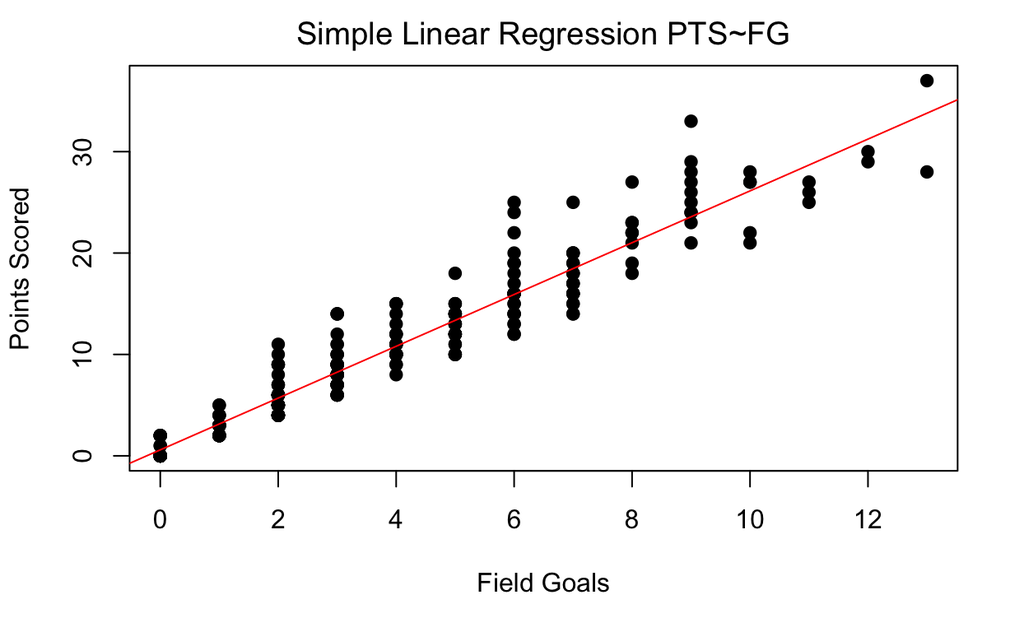

```r
par(family='Arial Unicode MS')
attach(df)
plot(FG, PTS, main="Simple Linear Regression PTS~FG", xlab="Field Goals", ylab="Points Scored", pch=19)
abline(lm(PTS~FG), col="red") # regression line (y~x)
```

```r
# train-test split
set.seed(1122)
index <- sample(1:nrow(df), 250)
train <- df[index, ]
test <- df[-index, ]
```

#### (c)

```r
require(psych)
print(corr.test(df[,8:ncol(df)], use="pairwise", method="pearson", adjust="holm", alpha=.05, ci=TRUE))
```

```
Call:corr.test(x = df[, 8:ncol(df)], use = "pairwise", method = "pearson",
    adjust = "holm", alpha = 0.05, ci = TRUE)
Correlation matrix
      MIN   FG  FGA   X3P  X3PA   FT  FTA    OR   DR  TOT    A   PF   ST   TO
MIN  1.00 0.69 0.79  0.40  0.55 0.45 0.45  0.33 0.54 0.55 0.50 0.34 0.37 0.46
FG   0.69 1.00 0.87  0.47  0.45 0.43 0.43  0.38 0.45 0.49 0.37 0.27 0.27 0.41
FGA  0.79 0.87 1.00  0.43  0.61 0.48 0.47  0.34 0.40 0.44 0.47 0.26 0.33 0.45
X3P  0.40 0.47 0.43  1.00  0.80 0.08 0.08 -0.06 0.06 0.03 0.24 0.14 0.19 0.14
X3PA 0.55 0.45 0.61  0.80  1.00 0.22 0.20 -0.05 0.10 0.07 0.35 0.15 0.30 0.24
FT   0.45 0.43 0.48  0.08  0.22 1.00 0.96  0.27 0.37 0.39 0.21 0.11 0.12 0.36
FTA  0.45 0.43 0.47  0.08  0.20 0.96 1.00  0.29 0.37 0.40 0.20 0.13 0.15 0.36
OR   0.33 0.38 0.34 -0.06 -0.05 0.27 0.29  1.00 0.40 0.66 0.02 0.25 0.02 0.20
DR   0.54 0.45 0.40  0.06  0.10 0.37 0.37  0.40 1.00 0.95 0.19 0.24 0.14 0.30
TOT  0.55 0.49 0.44  0.03  0.07 0.39 0.40  0.66 0.95 1.00 0.17 0.28 0.12 0.32
A    0.50 0.37 0.47  0.24  0.35 0.21 0.20  0.02 0.19 0.17 1.00 0.19 0.27 0.33
PF   0.34 0.27 0.26  0.14  0.15 0.11 0.13  0.25 0.24 0.28 0.19 1.00 0.07 0.33
ST   0.37 0.27 0.33  0.19  0.30 0.12 0.15  0.02 0.14 0.12 0.27 0.07 1.00 0.07
TO   0.46 0.41 0.45  0.14  0.24 0.36 0.36  0.20 0.30 0.32 0.33 0.33 0.07 1.00
BL   0.24 0.23 0.22 -0.04 -0.01 0.16 0.16  0.34 0.37 0.41 0.03 0.13 0.00 0.20
PTS  0.72 0.96 0.87  0.54  0.54 0.64 0.63  0.35 0.46 0.49 0.38 0.26 0.27 0.44
        BL  PTS
MIN   0.24 0.72
FG    0.23 0.96
FGA   0.22 0.87
X3P  -0.04 0.54
X3PA -0.01 0.54
FT    0.16 0.64
FTA   0.16 0.63
OR    0.34 0.35
DR    0.37 0.46
TOT   0.41 0.49
A     0.03 0.38
PF    0.13 0.26
ST    0.00 0.27
TO    0.20 0.44
BL    1.00 0.22
PTS   0.22 1.00
Sample Size
[1] 269
Probability values (Entries above the diagonal are adjusted for multiple tests.)
     MIN FG FGA  X3P X3PA   FT  FTA   OR   DR  TOT    A   PF   ST   TO   BL  PTS
MIN    0  0   0 0.00 0.00 0.00 0.00 0.00 0.00 0.00 0.00 0.00 0.00 0.00 0.00 0.00
FG     0  0   0 0.00 0.00 0.00 0.00 0.00 0.00 0.00 0.00 0.00 0.00 0.00 0.00 0.00
FGA    0  0   0 0.00 0.00 0.00 0.00 0.00 0.00 0.00 0.00 0.00 0.00 0.00 0.01 0.00
X3P    0  0   0 0.00 0.00 1.00 1.00 1.00 1.00 1.00 0.00 0.42 0.06 0.47 1.00 0.00
X3PA   0  0   0 0.00 0.00 0.01 0.03 1.00 1.00 1.00 0.00 0.37 0.00 0.00 1.00 0.00
FT     0  0   0 0.18 0.00 0.00 0.00 0.00 0.00 0.00 0.02 1.00 0.93 0.00 0.26 0.00
FTA    0  0   0 0.19 0.00 0.00 0.00 0.00 0.00 0.00 0.03 0.64 0.37 0.00 0.27 0.00
OR     0  0   0 0.33 0.39 0.00 0.00 0.00 0.00 0.00 1.00 0.00 1.00 0.03 0.00 0.00
DR     0  0   0 0.37 0.10 0.00 0.00 0.00 0.00 0.00 0.04 0.00 0.44 0.00 0.00 0.00
TOT    0  0   0 0.68 0.29 0.00 0.00 0.00 0.00 0.00 0.18 0.00 0.80 0.00 0.00 0.00
A      0  0   0 0.00 0.00 0.00 0.00 0.70 0.00 0.01 0.00 0.06 0.00 0.00 1.00 0.00
PF     0  0   0 0.02 0.01 0.07 0.03 0.00 0.00 0.00 0.00 0.00 1.00 0.00 0.79 0.00
ST     0  0   0 0.00 0.00 0.05 0.01 0.73 0.02 0.04 0.00 0.26 0.00 1.00 1.00 0.00
TO     0  0   0 0.02 0.00 0.00 0.00 0.00 0.00 0.00 0.00 0.00 0.28 0.00 0.03 0.00
BL     0  0   0 0.53 0.93 0.01 0.01 0.00 0.00 0.00 0.63 0.04 0.95 0.00 0.00 0.01
PTS    0  0   0 0.00 0.00 0.00 0.00 0.00 0.00 0.00 0.00 0.00 0.00 0.00 0.00 0.00

 To see confidence intervals of the correlations, print with the short=FALSE option
```

We can see that other predictors like FGA, MIN, and FT, have high correlation with PTS. So we choose them as regressors.

```r
par(family='Arial Unicode MS')
par(mfrow=c(1,3))
attach(df)
plot(FGA, PTS, main="Correlation plot (PTS~FGA)", xlab="Field Goals Attempted", ylab="Points Scored", pch=19, col='red')
plot(MIN, PTS, main="Correlation plot (PTS~MIN)", xlab="Minutes Played", ylab="Points Scored", pch=19, col='green')
```

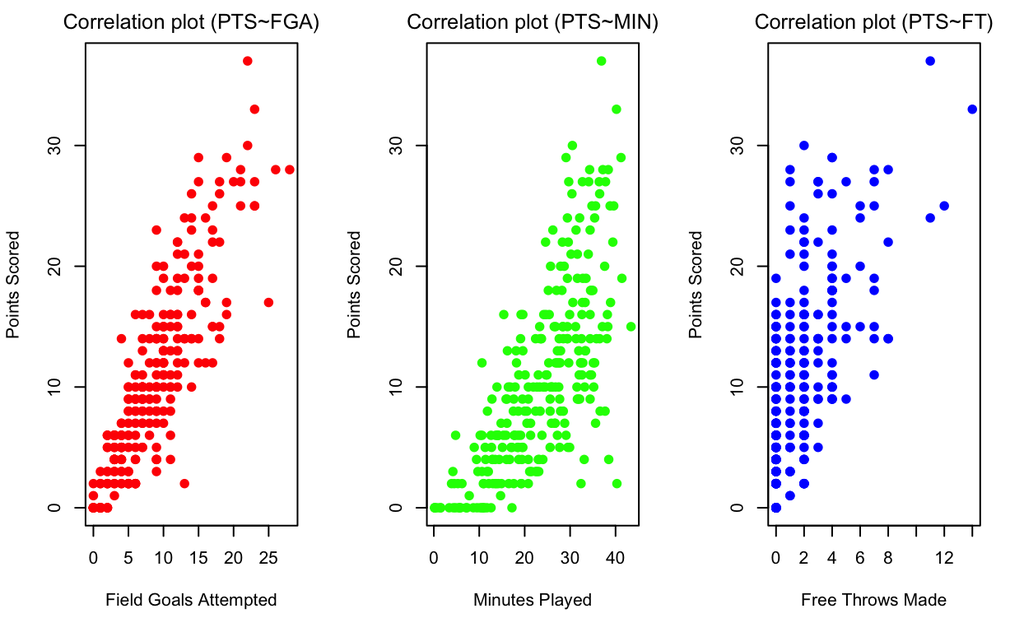

```r
plot(FT, PTS, main="Correlation plot (PTS~FT)", xlab="Free Throws Made", ylab="Points Scored", pch=19, col='blue')
```

#### (d)

```r
# multiple regression
mr <- lm(PTS ~ FG + FGA + MIN + FT, data=train)
summary(mr)
```

```
Call:
lm(formula = PTS ~ FG + FGA + MIN + FT, data = train)

Residuals:
    Min      1Q  Median      3Q     Max
-2.3511 -0.7169 -0.1320  0.4964  5.1925

Coefficients:
             Estimate Std. Error t value Pr(>|t|)
(Intercept) -0.185670   0.189855  -0.978    0.329
FG           2.171340   0.050138  43.307   <2e-16 ***
FGA          0.007994   0.030389   0.263    0.793
MIN          0.025514   0.011691   2.182    0.030 *
FT           0.897187   0.035081  25.575   <2e-16 ***
---
Signif. codes:  0 ‘***’ 0.001 ‘**’ 0.01 ‘*’ 0.05 ‘.’ 0.1 ‘ ’ 1

Residual standard error: 1.138 on 245 degrees of freedom
Multiple R-squared:  0.9795,    Adjusted R-squared:  0.9791
F-statistic:  2919 on 4 and 245 DF,  p-value: < 2.2e-16
```

According to p-values in the last column, lower p-values indicates larger statistical significance, so FG, FT, and MIN are statistically significant predictors, while FGA are not, which will be eliminated.

Evaluation: The high R-squared value 0.9791 statistically measures the data are close to the fitted regression line. The overall p-value of F-statistic 2919 on 4 and 245 Degree of Freedom is extremely small, i.e. smaller that 0.001 so we can reject H0 (Additional variables except intercept do not provide value taken together) and say that overall addition of variables is significantly improving the model. So the model fits very well.

#### (e)

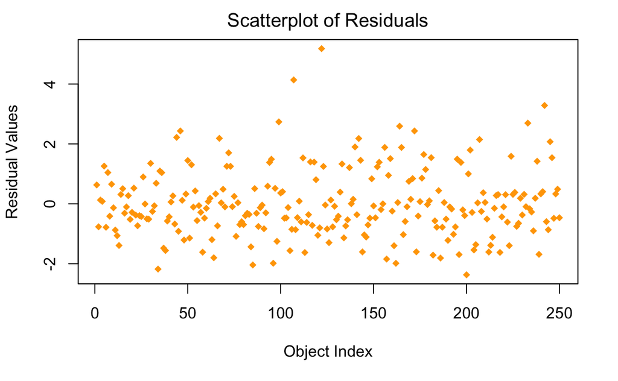

```r
# modified model, eliminate FGA
mr2 <- lm(PTS ~ FG + MIN + FT, data=train)
par(family='Arial Unicode MS')
plot(resid(mr2), pch=18, col='orange', main="Scatterplot of Residuals", xlab='Object Index', ylab='Residual Values')
```

There is no obvious shape of scatterplot of the residuals. But objects tend to be densely distributed near 0 residual, and gradually get sparsed as far with 0 residual.

#### (f)

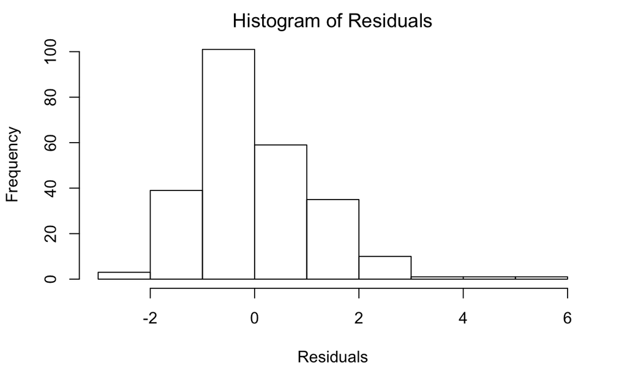

```r
par(family='Arial Unicode MS')
hist(resid(mr2), main="Histogram of Residuals", xlab="Residuals")
```

```r
pred <- predict(mr2, test)
pred_r <- as.integer(round(pred))
eval <- data.frame(pred_r, test[, ncol(test)])
eval
```

| pred_r | test...ncol.test.. |
| --- | --- |
| 13 | 12 |
| 8 | 9 |
| 14 | 14 |
| 10 | 12 |
| 17 | 17 |
| 2 | 3 |
| 0 | 0 |
| 5 | 6 |
| 5 | 4 |
| 2 | 2 |

[output cut: 9 more lines]

```r
sum(eval[,1]==eval[,2])
```

```
[1] 7
```

Among 19 test objects, there are 7 objects whose fitted PTS value exactly matches its actaul PTS value.

#### (h)

```r
# calculate residual vector for the predictions on the test set
resid_t <- eval[,2] - pred
rss = sum(resid_t^2)
tss = sum((eval[,2] - mean(eval[,2]))^2)
n = nrow(test)                  # number of objects
k = length(mr2$coefficients)    # number of model parameters
# The degree of freedom for residual, total, and model, are n-k, n-1, k-1, respectively.
fstat = (tss-rss)/(k-1) / (rss/(n-k))
rse = sqrt(rss/(n-k))

cat("RSS (Residual Sum of Squares):", "\t", rss, "\n")
```

```
RSS (Residual Sum of Squares):   9.987332
```

```r
cat("TSS (Total Sum of Squares):", "\t", tss, "\n")
```

```
TSS (Total Sum of Squares):      446.7368
```

```r
cat("F-statistic:", "\t", fstat, "\n")
```

```
F-statistic:     218.6518
```

```r
cat("RSE (Residual Standard Error):", "\t", rse)
```

```
RSE (Residual Standard Error):   0.8159792
```